# Relatório de Gráficos em R — Engenharia Civil

Disciplina: Estatística Aplicada a Inovações Tecnológicas

2026-09-21

## Contexto

Este relatório tem como objetivo aplicar os principais sistemas gráficos do R — **Base R**, **ggplot2**, **plotly**, **highcharter** e **leaflet** — a um banco de dados da área de **Engenharia Civil**. O banco contém informações sobre 300 obras, incluindo tipo, região, área construída, custo, prazo, resistência do concreto, consumo de cimento, índice de falhas, satisfação do cliente e adoção de práticas sustentáveis.

O foco é **explorar, comunicar e interpretar** os dados por meio de gráficos, escolhendo a geometria e o sistema mais adequado para cada pergunta.

## Carregando pacotes e dados

```r
library(ggplot2)
library(dplyr)
library(plotly)
library(highcharter)
library(leaflet)
library(scales)

dados <- read.csv("dados_engenharia_civil.csv")

glimpse(dados)
```

```
## Rows: 300
## Columns: 11
## $ id_obra         <int> 1, 2, 3, 4, 5, 6, 7, 8, 9, 10, 11, 12, 13, 14, 15, 16,…
## $ tipo_obra       <chr> "Industrial", "Comercial", "Residencial", "Residencial…
## $ regiao          <chr> "Nordeste", "Nordeste", "Sul", "Sudeste", "Centro-Oest…
## $ area_construida <dbl> 802.5, 791.5, 575.4, 1156.6, 581.5, 606.9, 572.7, 1380…
## $ custo_total     <dbl> 1608825.8, 2870991.8, 1683605.5, 3469884.2, 2176258.5,…
## $ prazo_meses     <int> 36, 20, 13, 23, 28, 27, 20, 15, 35, 15, 36, 23, 32, 12…
## $ resistencia_mpa <dbl> 26.80, 28.05, 33.12, 31.06, 28.29, 32.94, 35.05, 42.62…
## $ consumo_cimento <dbl> 393.1, 394.1, 387.0, 368.7, 389.4, 329.8, 422.6, 347.3…
## $ indice_falhas   <int> 1, 2, 4, 1, 2, 4, 1, 2, 0, 1, 0, 1, 2, 1, 1, 3, 1, 1, …
## $ satisfacao      <dbl> 6.2, 7.8, 3.8, 3.8, 6.7, 1.0, 9.7, 8.8, 7.6, 5.1, 2.6,…
## $ sustentavel     <chr> "Sim", "Sim", "Não", "Sim", "Sim", "Sim", "Não", "Não"…
```

## 1. Gráficos no Base R

### 1.1 Dispersão: área construída × custo total

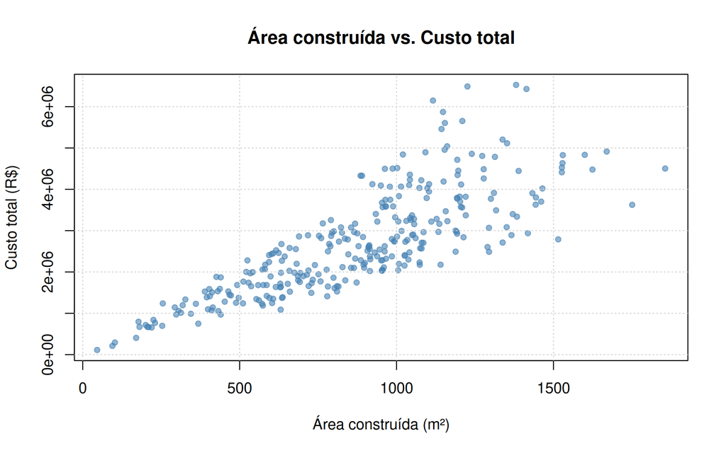

```r
plot(
  dados$area_construida,
  dados$custo_total,
  main = "Área construída vs. Custo total",
  xlab = "Área construída (m²)",
  ylab = "Custo total (R$)",
  pch  = 19,
  col  = adjustcolor("steelblue", alpha.f = 0.6),
  cex  = 0.8
)
grid()
```

**Interpretação esperada:** verificar se há relação linear positiva entre área e custo, e se existem *outliers* que fogem do padrão.

### 1.2 Histograma: resistência do concreto

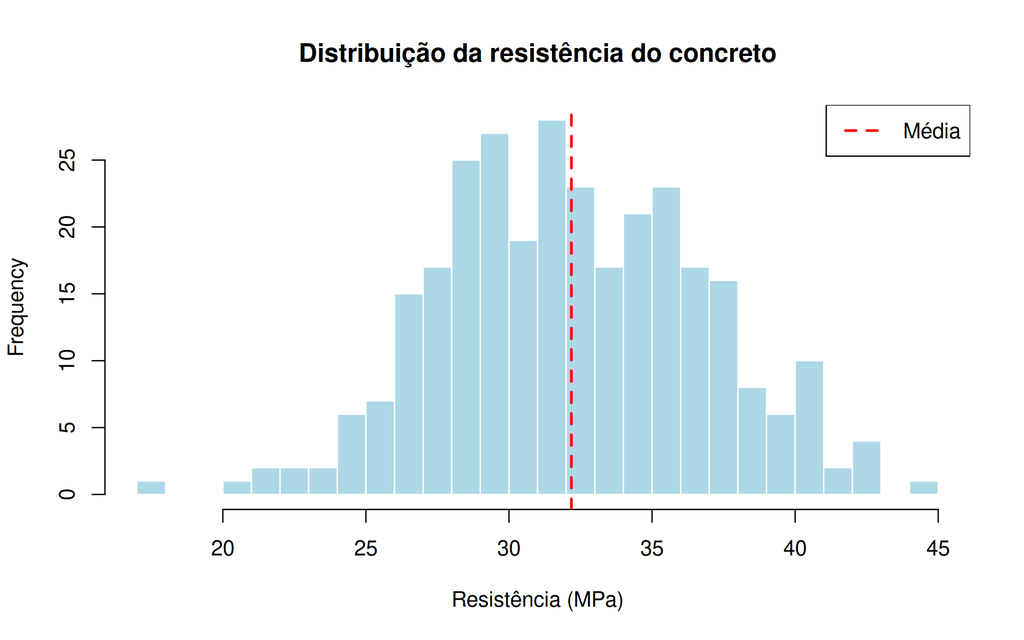

```r
hist(
  dados$resistencia_mpa,
  breaks = 20,
  col    = "lightblue",
  border = "white",
  main   = "Distribuição da resistência do concreto",
  xlab   = "Resistência (MPa)"
)
abline(v = mean(dados$resistencia_mpa), col = "red", lwd = 2, lty = 2)
legend("topright", legend = "Média", col = "red", lty = 2, lwd = 2)
```

**Interpretação esperada:** avaliar simetria, dispersão e possíveis valores fora do intervalo típico de projeto.

### 1.3 Boxplot: custo total por tipo de obra

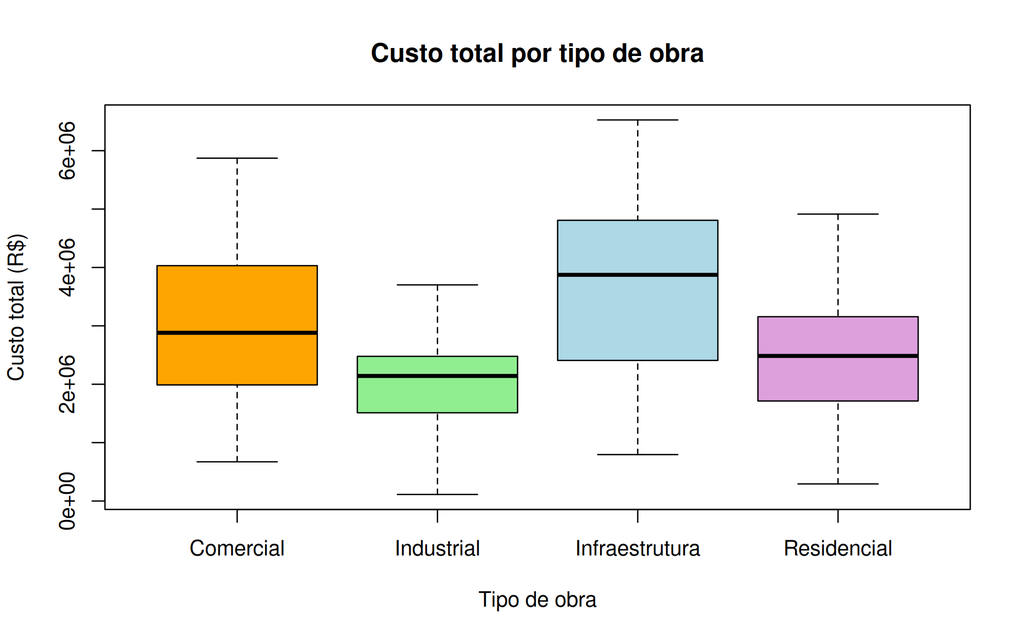

```r
boxplot(
  custo_total ~ tipo_obra,
  data = dados,
  col  = c("orange", "lightgreen", "lightblue", "plum"),
  main = "Custo total por tipo de obra",
  xlab = "Tipo de obra",
  ylab = "Custo total (R$)"
)
```

**Interpretação esperada:** comparar medianas e variabilidade entre categorias; identificar qual tipo de obra é mais caro e mais heterogêneo.

### 1.4 Barplot: contagem por região

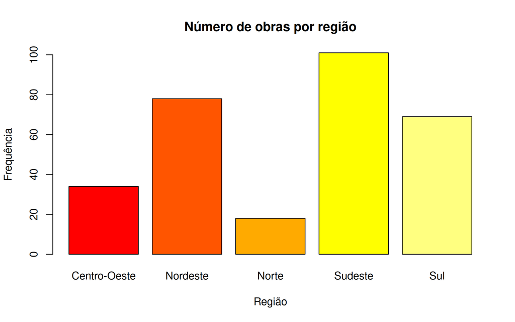

```r
tab <- table(dados$regiao)

barplot(
  tab,
  col    = heat.colors(length(tab)),
  main   = "Número de obras por região",
  xlab   = "Região",
  ylab   = "Frequência"
)
```

## 2. Gráficos com ggplot2

### 2.1 Dispersão com cor por tipo de obra

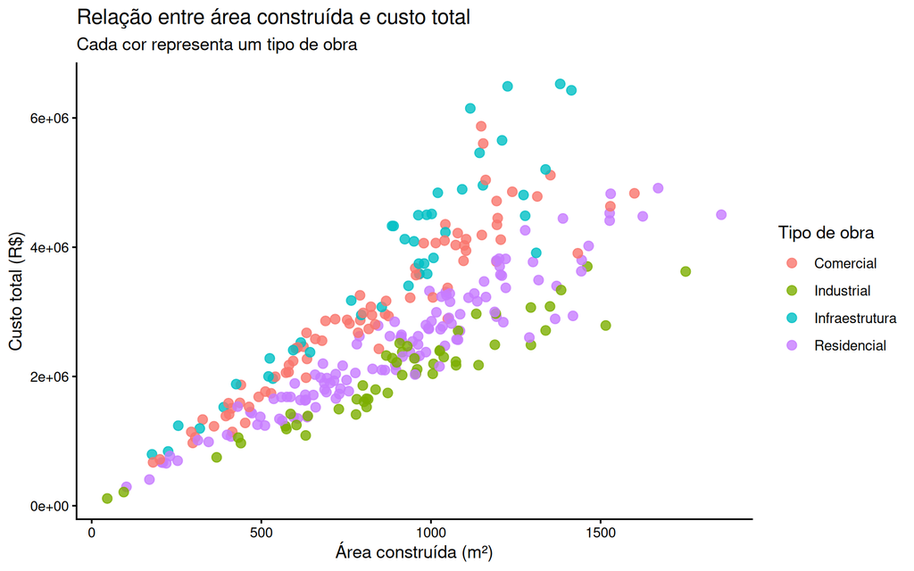

```r
ggplot(dados, aes(x = area_construida, y = custo_total, color = tipo_obra)) +
  geom_point(size = 2.5, alpha = 0.8) +
  labs(
    title = "Relação entre área construída e custo total",
    subtitle = "Cada cor representa um tipo de obra",
    x = "Área construída (m²)",
    y = "Custo total (R$)",
    color = "Tipo de obra"
  ) +
  theme_classic()
```

### 2.2 Boxplot com preenchimento por tipo

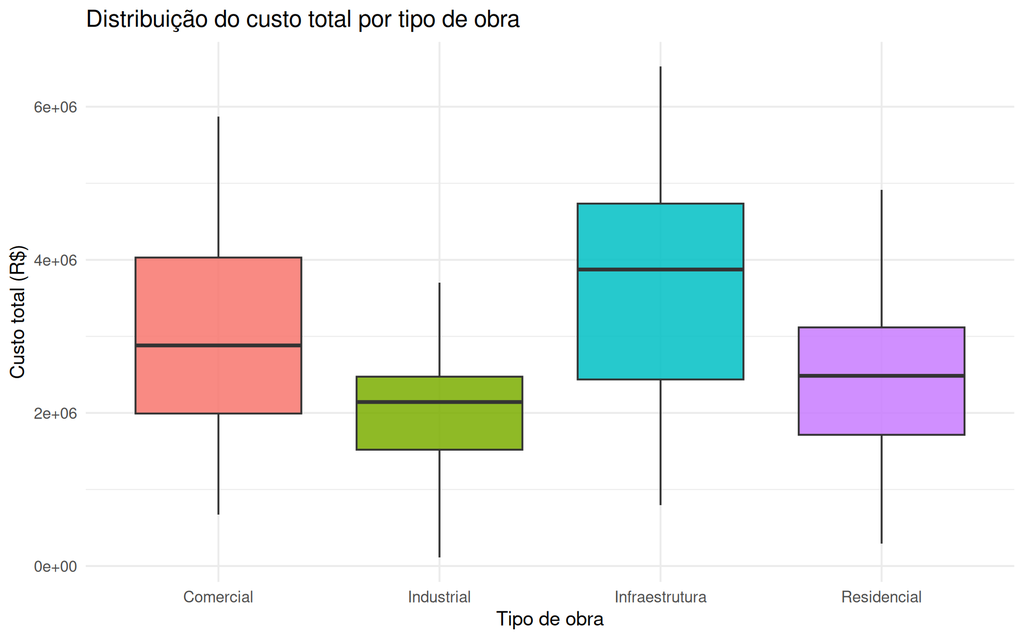

```r
ggplot(dados, aes(x = tipo_obra, y = custo_total, fill = tipo_obra)) +
  geom_boxplot(alpha = 0.85, outlier.color = "red") +
  labs(
    title = "Distribuição do custo total por tipo de obra",
    x = "Tipo de obra",
    y = "Custo total (R$)"
  ) +
  theme_minimal() +
  theme(legend.position = "none")
```

### 2.3 Histograma com densidade

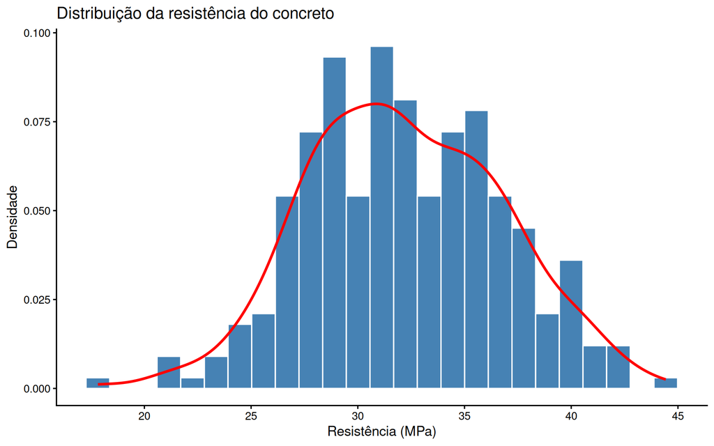

```r
ggplot(dados, aes(x = resistencia_mpa)) +
  geom_histogram(aes(y = after_stat(density)),
                 bins = 25, fill = "steelblue", color = "white") +
  geom_density(color = "red", linewidth = 1) +
  labs(
    title = "Distribuição da resistência do concreto",
    x = "Resistência (MPa)",
    y = "Densidade"
  ) +
  theme_classic()
```

### 2.4 Barras: obras sustentáveis por tipo

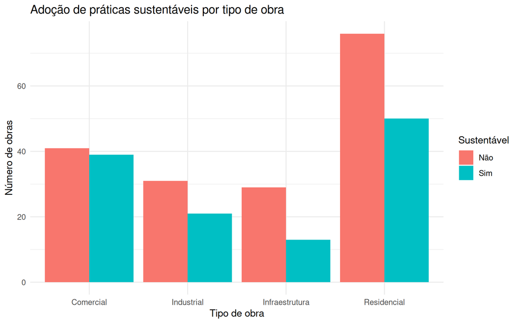

```r
ggplot(dados, aes(x = tipo_obra, fill = sustentavel)) +
  geom_bar(position = "dodge") +
  labs(
    title = "Adoção de práticas sustentáveis por tipo de obra",
    x = "Tipo de obra",
    y = "Número de obras",
    fill = "Sustentável"
  ) +
  theme_minimal()
```

### 2.5 Facetas: área × custo por região

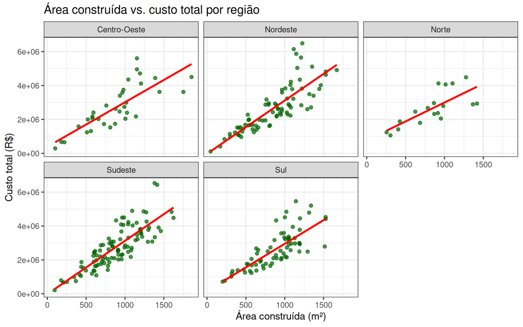

```r
ggplot(dados, aes(x = area_construida, y = custo_total)) +
  geom_point(color = "darkgreen", alpha = 0.7) +
  geom_smooth(method = "lm", se = FALSE, color = "red") +
  facet_wrap(~regiao, ncol = 3) +
  labs(
    title = "Área construída vs. custo total por região",
    x = "Área construída (m²)",
    y = "Custo total (R$)"
  ) +
  theme_bw()
```

### 2.6 Gráfico final com múltiplas camadas

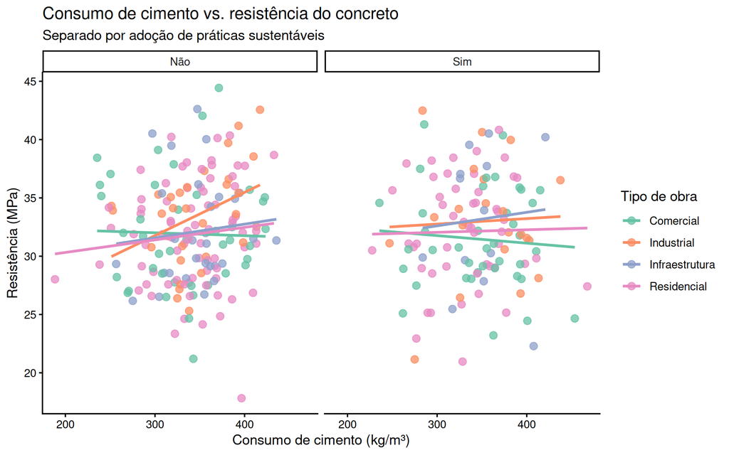

```r
ggplot(dados, aes(x = consumo_cimento, y = resistencia_mpa, color = tipo_obra)) +
  geom_point(size = 2.5, alpha = 0.75) +
  geom_smooth(method = "lm", se = FALSE, linewidth = 1) +
  facet_wrap(~sustentavel) +
  scale_color_brewer(palette = "Set2") +
  labs(
    title = "Consumo de cimento vs. resistência do concreto",
    subtitle = "Separado por adoção de práticas sustentáveis",
    x = "Consumo de cimento (kg/m³)",
    y = "Resistência (MPa)",
    color = "Tipo de obra"
  ) +
  theme_classic()
```

## 3. Gráficos interativos com plotly

### 3.1 Dispersão interativa

```r
p <- ggplot(dados, aes(x = area_construida, y = custo_total,
                       color = tipo_obra, text = paste("Obra:", id_obra))) +
  geom_point(size = 2.5, alpha = 0.8) +
  labs(
    title = "Área × Custo (interativo)",
    x = "Área construída (m²)",
    y = "Custo total (R$)",
    color = "Tipo de obra"
  ) +
  theme_minimal()

ggplotly(p, tooltip = c("text", "x", "y", "color"))
```

[interactive chart not shown]

**Sugestão de exploração:** passar o mouse sobre os pontos para identificar obras com custo atípico e verificar se pertencem a algum tipo específico.

## 4. Gráficos com highcharter

### 4.1 Custo médio por tipo de obra

```r
dados |>
  group_by(tipo_obra) |>
  summarise(custo_medio = mean(custo_total)) |>
  hchart("column", hcaes(x = tipo_obra, y = custo_medio)) |>
  hc_title(text = "Custo médio por tipo de obra") |>
  hc_yAxis(title = list(text = "Custo médio (R$)")) |>
  hc_xAxis(title = list(text = "Tipo de obra"))
```

[interactive chart not shown]

```r
dados |>
  group_by(regiao) |>
  summarise(prazo_medio = mean(prazo_meses)) |>
  hchart("line", hcaes(x = regiao, y = prazo_medio)) |>
  hc_title(text = "Prazo médio por região") |>
  hc_yAxis(title = list(text = "Meses"))
```

[interactive chart not shown]

### 4.3 Pizza: participação de cada tipo de obra

```r
dados |>
  count(tipo_obra) |>
  hchart("pie", hcaes(name = tipo_obra, y = n)) |>
  hc_title(text = "Participação por tipo de obra")
```

[interactive chart not shown]

## 5. Mapas interativos com leaflet

### 5.1 Mapa base centralizado em Minas Gerais

```r
leaflet() |>
  addProviderTiles(providers$CartoDB.Positron) |>
  setView(lng = -44.5, lat = -19.0, zoom = 6)
```

[interactive chart not shown]

### 5.2 Marcadores para obras por região (coordenadas aproximadas)

```r
obras_regiao <- data.frame(
  regiao = c("Sudeste", "Sul", "Nordeste", "Centro-Oeste", "Norte"),
  lat    = c(-19.9, -25.4, -8.0, -15.8, -3.1),
  lon    = c(-43.9, -49.3, -34.9, -47.9, -60.0),
  n      = as.integer(table(dados$regiao))
)

leaflet(obras_regiao) |>
  addTiles() |>
  addMarkers(
    lng = ~lon, lat = ~lat,
    popup = ~paste0("<b>", regiao, "</b><br>Obras: ", n)
  )
```

[interactive chart not shown]

**Sugestão de exploração:** relacionar o número de obras com o custo médio regional e discutir implicações logísticas.

## 6. Perguntas orientadoras para o relatório

1. Existe relação entre **área construída** e **custo total**? Essa relação é a mesma em todas as regiões?
2. Qual **tipo de obra** apresenta maior custo médio e maior variabilidade?
3. A **resistência do concreto** segue uma distribuição aproximadamente normal? Há valores fora do intervalo típico de projeto?
4. O **consumo de cimento** está associado à **resistência**? Essa associação muda quando a obra é sustentável?
5. Há diferença no **prazo médio** entre regiões? Alguma região se destaca?
6. A **satisfação do cliente** está relacionada ao **índice de falhas**?
7. A adoção de **práticas sustentáveis** está concentrada em algum tipo de obra?

## 7. Entregáveis

- Um **RMarkdown** (`relatorio.Rmd`) renderizado em HTML com todos os gráficos.
- Pelo menos **um gráfico de cada sistema**: Base R, ggplot2, plotly, highcharter e leaflet.
- **Comentário interpretativo** de 3 a 5 linhas abaixo de cada gráfico, explicando o que o gráfico revela sobre os dados.
- Um **gráfico final autoral** que responda a uma das perguntas orientadoras, combinando pelo menos **duas camadas** (ex.: `geom_point()` + `geom_smooth()` + `facet_wrap()`).
- Entrega em repositório Git ou arquivo `.zip` com o `.Rmd`, o CSV e o HTML renderizado.